# 04_Codebook

Chiara Draxler

31 5 2022

#Introduction for working code:

0. Download the Code from Github. The new downloaded folder hc_switch_cccu-main contains the R project, Rmd Code, created data frames, knitted Html Code, Figures as .pdf and.jpg, Preregistered synthetic Code, and a folder to store the downloaded RData called RData.

Name the folder appropriately (when downloading the code from GitHub the folder will be hc_switch_cccu-main).

1. Download data from https://www.icpsr.umich.edu/web/DSDR/studies/37067/datadocumentation

Attention! The downloaded project from GitHub does not contain any data files!

–> Click on Download, then select R, then follow the login –> store data in the folder specific to the R project in an extra sub-folder called RData (i.e., hc_switch_cccu-main - > RData). If you downloaded the code from GitHub, the RData folder will be already in the hc_switch_cccu-main projects folder.

–> Within the RData folder store data for wave 1 in DS0001, for wave 2 in DS0002 and so on (i.e., hc_switch_cccu-main - > RData -> DS0001 ). If you downloaded the code from GitHub, the relevant folders will be already there.

–> name the Rdata files according to the wave:

Wave 1: 37067-0001-Data (i.e., hc_switch_cccu-main - > RData -> DS0001 -> 37067-0001-Data.rda )

Wave 2: 37067-0002-Data (i.e., hc_switch_cccu-main - > RData -> DS0002 -> 37067-0002-Data.rda )

Wave 3: 37067-0003-Data (i.e., hc_switch_cccu-main - > RData -> DS0003 -> 37067-0003-Data.rda )

Wave 4: 37067-0004-Data (i.e., hc_switch_cccu-main - > RData -> DS0004 -> 37067-0004-Data.rda )

–> attention to the .rda ending when loading the data into R!

2. make sure to install all relevant packages before running the code!

```r
library(ggplot2)
theme_set(theme_bw())
library(codebook)
library(tidyverse)
library(future)
library(psych)
library(Hmisc)
load("cccu_MA.RData")
```

## 2. Select data

```r
cccu_MA = cccu_MA %>%
  select(WAVE, switch, hc, contra_satis, hc_dur, sexual_satisfaction, sex_freq,
         AGE, DEGREE_recode, POVRATE, HLTHPROB_recode, MEDPROB_recode, GAPINS_recode, TYPEINS_recode, NKIDS_t1, pregnant_between_waves, had_baby_between_waves, Avoid_r, FEELPG_recode, rel_dur_factor)
```

## 3. Codebook

```r
codebook(cccu_MA, missingness_report = FALSE, indent = "###")
```

### Metadata

#### Description

**Dataset name**: cccu_MA

The dataset has N=3787 rows and 20 columns. 2285 rows have no missing values on any column.

**Metadata for search engines**

- **Date published**: 2022-08-13

| x |
| --- |
| WAVE |
| switch |
| hc |
| contra_satis |
| hc_dur |
| sexual_satisfaction |
| sex_freq |
| AGE |
| DEGREE_recode |
| POVRATE |
| HLTHPROB_recode |
| MEDPROB_recode |
| GAPINS_recode |
| TYPEINS_recode |
| NKIDS_t1 |
| pregnant_between_waves |
| had_baby_between_waves |
| Avoid_r |
| FEELPG_recode |
| rel_dur_factor |

###Variables

##### WAVE

###### Distribution

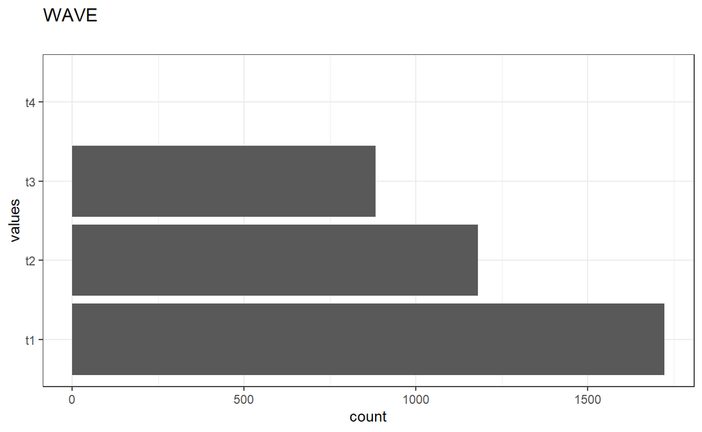

Distribution of values for WAVE

0 missing values.

###### Summary statistics

| name | data_type | ordered | value_labels | n_missing | complete_rate | n_unique | top_counts | label |
| --- | --- | --- | --- | --- | --- | --- | --- | --- |
| WAVE | factor | FALSE | 1. t1, 2. t2, 3. t3, 4. t4 | 0 | 1 | 3 | t1: 1723, t2: 1181, t3: 883, t4: 0 | NA |

##### switch

###### Distribution

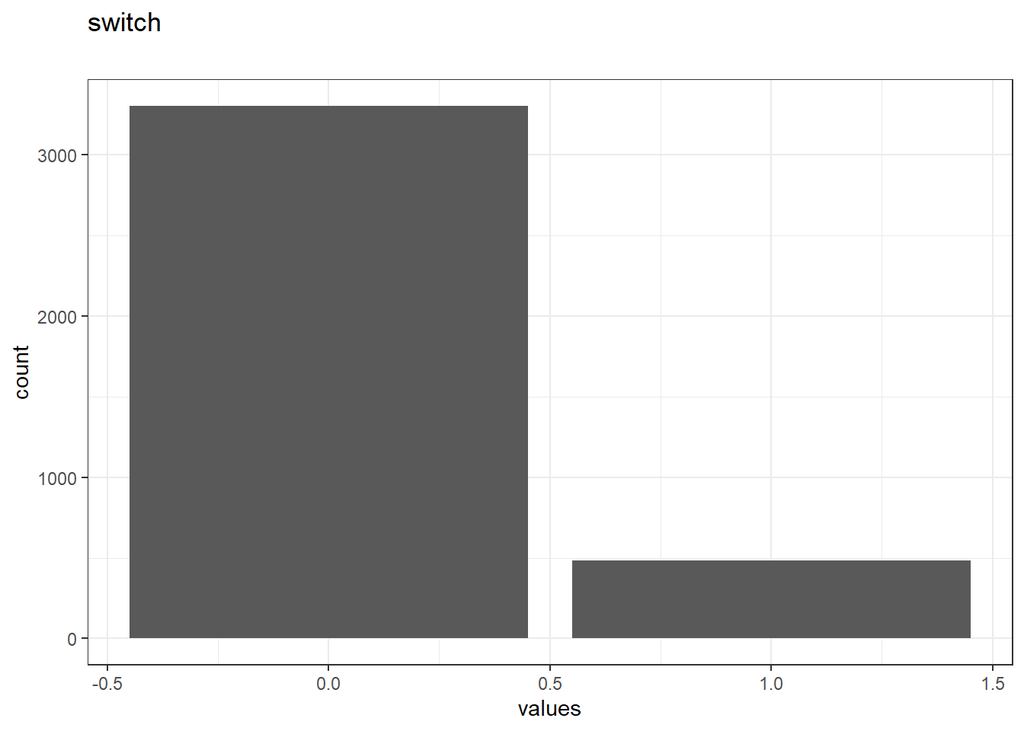

Distribution of values for switch

0 missing values.

###### Summary statistics

| name | data_type | n_missing | complete_rate | min | median | max | mean | sd | hist | label |
| --- | --- | --- | --- | --- | --- | --- | --- | --- | --- | --- |
| switch | numeric | 0 | 1 | 0 | 0 | 1 | 0.1280697 | 0.3342115 | ▇▁▁▁▁ | NA |

##### hc

###### Distribution

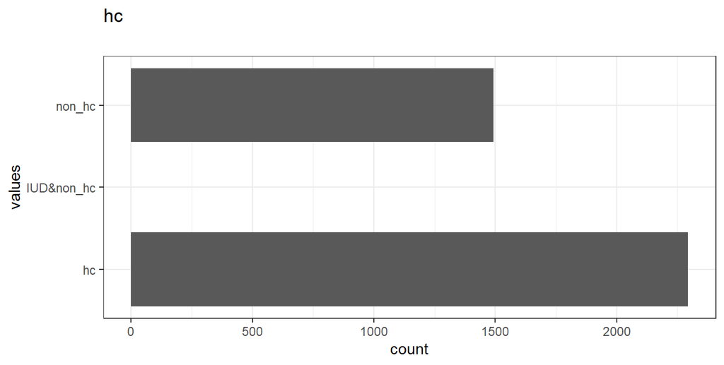

Distribution of values for hc

0 missing values.

###### Summary statistics

| name | data_type | ordered | value_labels | n_missing | complete_rate | n_unique | top_counts | label |
| --- | --- | --- | --- | --- | --- | --- | --- | --- |
| hc | factor | FALSE | 1. hc, 2. non_hc, 3. IUD&non_hc | 0 | 1 | 2 | hc: 2294, non: 1493, IUD: 0 | NA |

##### contra_satis

###### Distribution

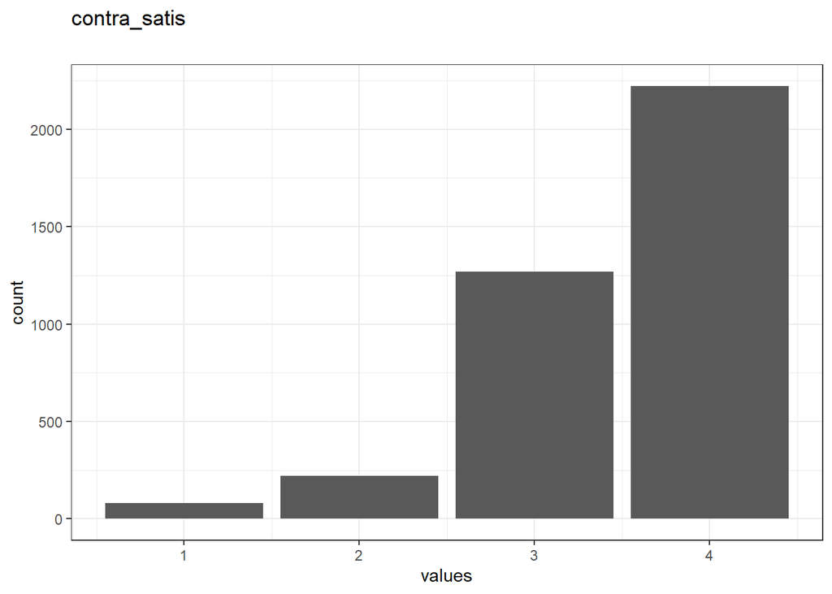

Distribution of values for contra_satis

0 missing values.

###### Summary statistics

| name | data_type | n_missing | complete_rate | min | median | max | mean | sd | hist | label |
| --- | --- | --- | --- | --- | --- | --- | --- | --- | --- | --- |
| contra_satis | numeric | 0 | 1 | 1 | 4 | 4 | 3.486137 | 0.7016738 | ▁▁▁▅▇ | NA |

##### hc_dur

###### Distribution

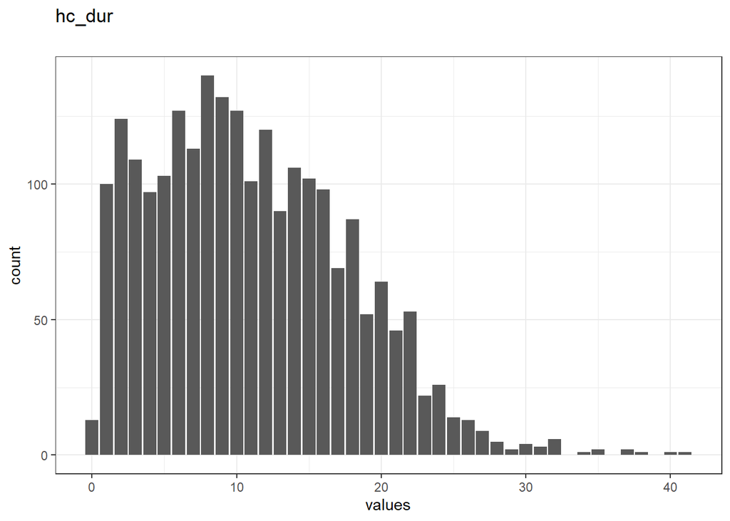

Distribution of values for hc_dur

1502 missing values.

###### Summary statistics

| name | data_type | n_missing | complete_rate | min | median | max | mean | sd | hist | label |
| --- | --- | --- | --- | --- | --- | --- | --- | --- | --- | --- |
| hc_dur | numeric | 1502 | 0.60338 | 0 | 10 | 41 | 10.98993 | 6.753113 | ▇▇▃▁▁ | NA |

##### sexual_satisfaction

###### Distribution

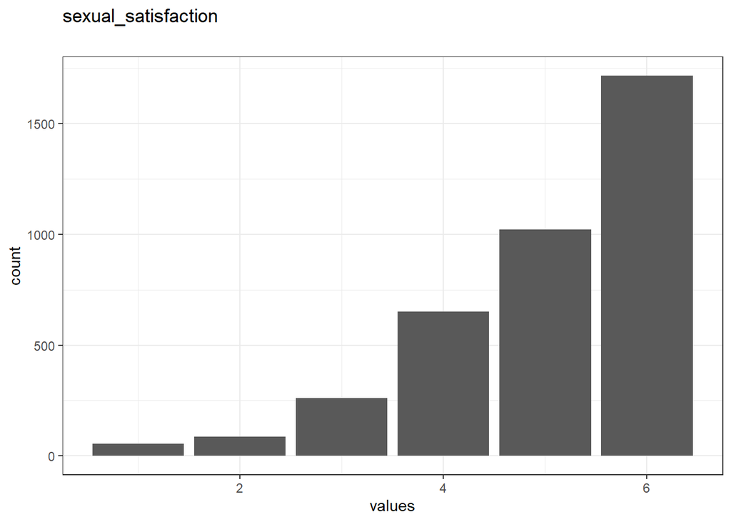

Distribution of values for sexual_satisfaction

0 missing values.

###### Summary statistics

| name | data_type | n_missing | complete_rate | min | median | max | mean | sd | hist | label |
| --- | --- | --- | --- | --- | --- | --- | --- | --- | --- | --- |
| sexual_satisfaction | numeric | 0 | 1 | 1 | 5 | 6 | 5.016636 | 1.156752 | ▁▁▃▅▇ | NA |

##### sex_freq

###### Distribution

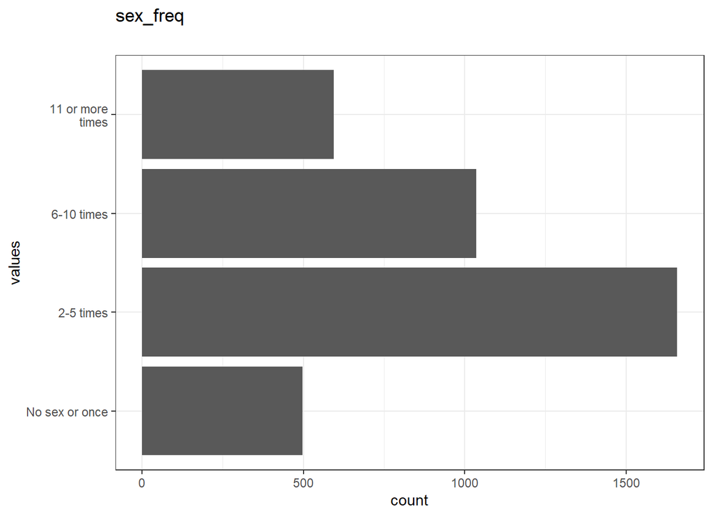

Distribution of values for sex_freq

0 missing values.

###### Summary statistics

| name | data_type | ordered | value_labels | n_missing | complete_rate | n_unique | top_counts | label |
| --- | --- | --- | --- | --- | --- | --- | --- | --- |
| sex_freq | factor | FALSE | 1. No sex or once, 2. 2-5 times, 3. 6-10 times, 4. 11 or more times | 0 | 1 | 4 | 2-5: 1659, 6-1: 1036, 11 : 594, No : 498 | NA |

##### AGE

###### Distribution

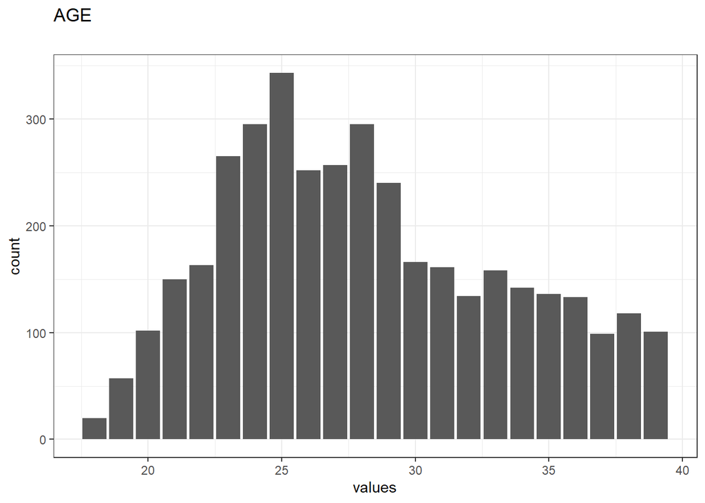

Distribution of values for AGE

0 missing values.

###### Summary statistics

| name | data_type | n_missing | complete_rate | min | median | max | mean | sd | hist | label |
| --- | --- | --- | --- | --- | --- | --- | --- | --- | --- | --- |
| AGE | numeric | 0 | 1 | 18 | 27 | 39 | 28.15289 | 5.209466 | ▃▇▆▅▅ | NA |

##### DEGREE_recode

###### Distribution

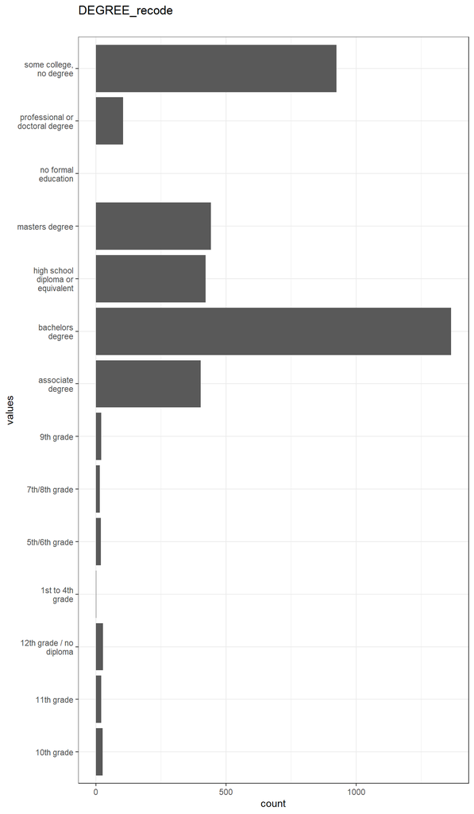

Distribution of values for DEGREE_recode

0 missing values.

###### Summary statistics

| name | data_type | ordered | value_labels | n_missing | complete_rate | n_unique | top_counts | label |
| --- | --- | --- | --- | --- | --- | --- | --- | --- |
| DEGREE_recode | factor | FALSE | 1. no formal education, 2. 1st to 4th grade, 3. 5th/6th grade, 4. 7th/8th grade, 5. 9th grade, 6. 10th grade, 7. 11th grade, 8. 12th grade / no diploma, 9. high school diploma or equivalent, 10. some … | 0 | 1 | 13 | bac: 1364, som: 924, mas: 442, hig: 421 | NA |

##### POVRATE

###### Distribution

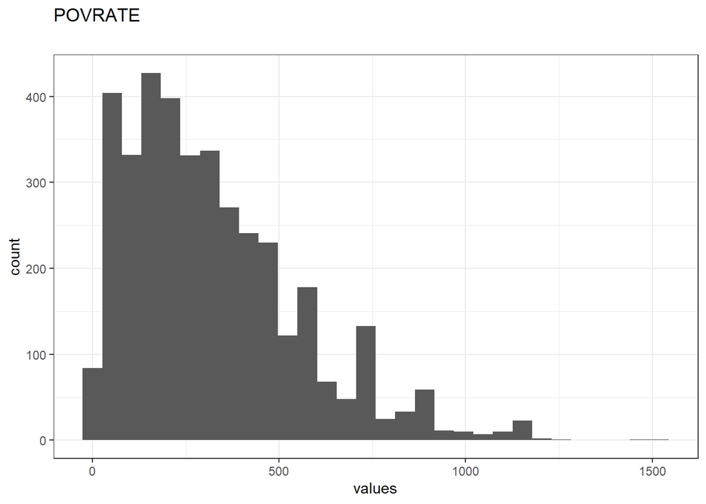

Distribution of values for POVRATE

0 missing values.

###### Summary statistics

| name | data_type | n_missing | complete_rate | min | median | max | mean | sd | hist | label |
| --- | --- | --- | --- | --- | --- | --- | --- | --- | --- | --- |
| POVRATE | numeric | 0 | 1 | 14 | 282 | 1532 | 320.1458 | 231.8161 | ▇▅▁▁▁ | NA |

##### HLTHPROB_recode

###### Distribution

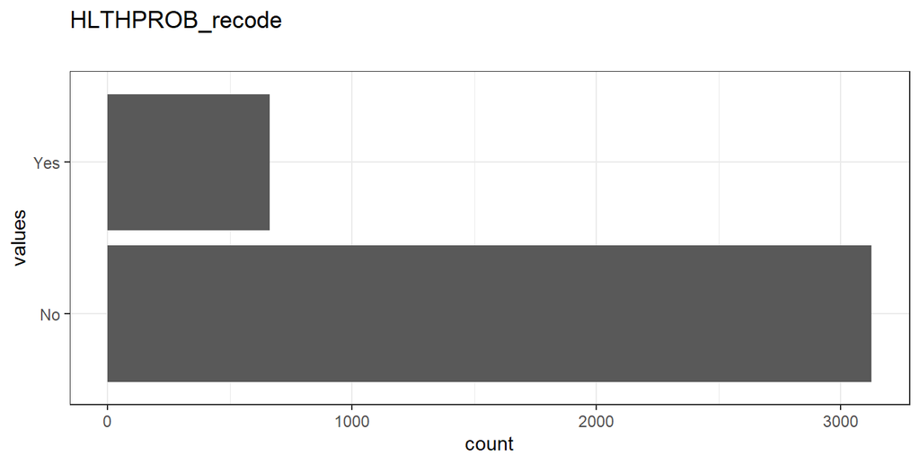

Distribution of values for HLTHPROB_recode

0 missing values.

###### Summary statistics

| name | data_type | ordered | value_labels | n_missing | complete_rate | n_unique | top_counts | label |
| --- | --- | --- | --- | --- | --- | --- | --- | --- |
| HLTHPROB_recode | factor | FALSE | 1. No, 2. Yes | 0 | 1 | 2 | No: 3125, Yes: 662 | NA |

##### MEDPROB_recode

###### Distribution

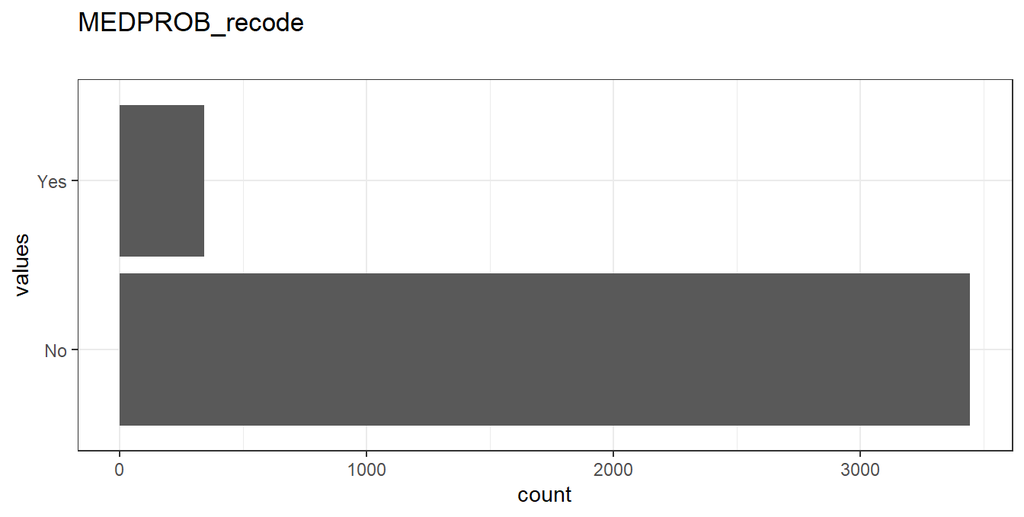

Distribution of values for MEDPROB_recode

0 missing values.

###### Summary statistics

| name | data_type | ordered | value_labels | n_missing | complete_rate | n_unique | top_counts | label |
| --- | --- | --- | --- | --- | --- | --- | --- | --- |
| MEDPROB_recode | factor | FALSE | 1. No, 2. Yes | 0 | 1 | 2 | No: 3444, Yes: 343 | NA |

##### GAPINS_recode

###### Distribution

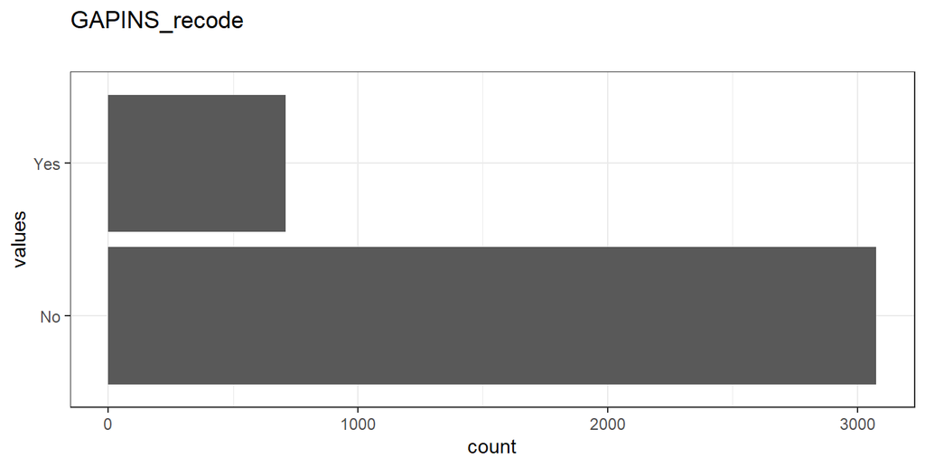

Distribution of values for GAPINS_recode

0 missing values.

###### Summary statistics

| name | data_type | ordered | value_labels | n_missing | complete_rate | n_unique | top_counts | label |
| --- | --- | --- | --- | --- | --- | --- | --- | --- |
| GAPINS_recode | factor | FALSE | 1. No, 2. Yes | 0 | 1 | 2 | No: 3076, Yes: 711 | NA |

##### TYPEINS_recode

###### Distribution

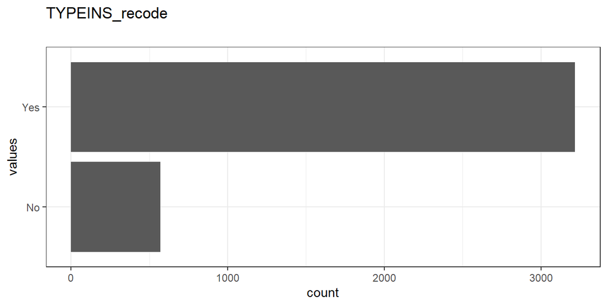

Distribution of values for TYPEINS_recode

0 missing values.

###### Summary statistics

| name | data_type | ordered | value_labels | n_missing | complete_rate | n_unique | top_counts | label |
| --- | --- | --- | --- | --- | --- | --- | --- | --- |
| TYPEINS_recode | factor | FALSE | 1. No, 2. Yes | 0 | 1 | 2 | Yes: 3218, No: 569 | NA |

##### NKIDS_t1

###### Distribution

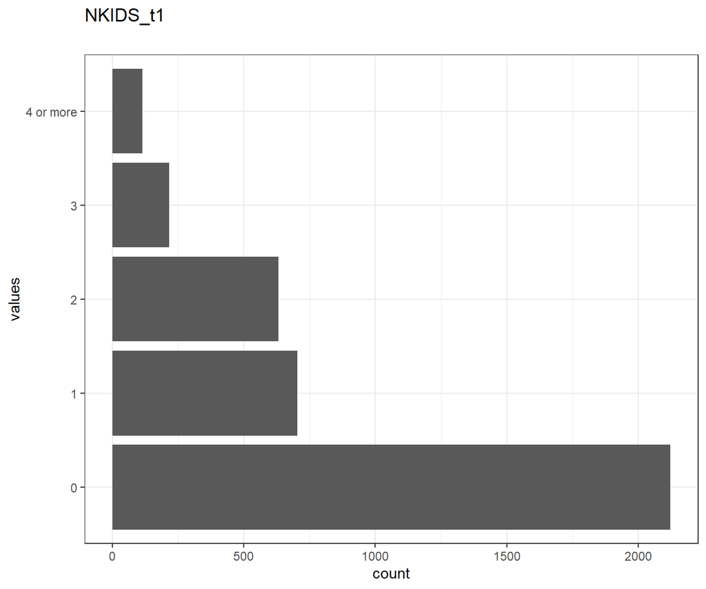

Distribution of values for NKIDS_t1

0 missing values.

###### Summary statistics

| name | data_type | ordered | value_labels | n_missing | complete_rate | n_unique | top_counts | label |
| --- | --- | --- | --- | --- | --- | --- | --- | --- |
| NKIDS_t1 | factor | FALSE | 1. 0, 2. 1, 3. 2, 4. 3, 5. 4 or more | 0 | 1 | 5 | 0: 2121, 1: 704, 2: 631, 3: 216 | NA |

##### pregnant_between_waves

###### Distribution

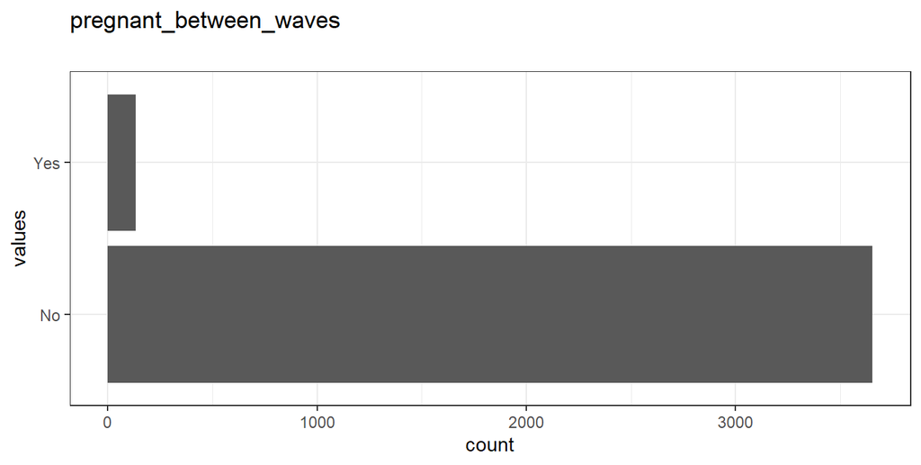

Distribution of values for pregnant_between_waves

0 missing values.

###### Summary statistics

| name | data_type | ordered | value_labels | n_missing | complete_rate | n_unique | top_counts | label |
| --- | --- | --- | --- | --- | --- | --- | --- | --- |
| pregnant_between_waves | factor | FALSE | 1. No, 2. Yes | 0 | 1 | 2 | No: 3655, Yes: 132 | NA |

##### had_baby_between_waves

###### Distribution

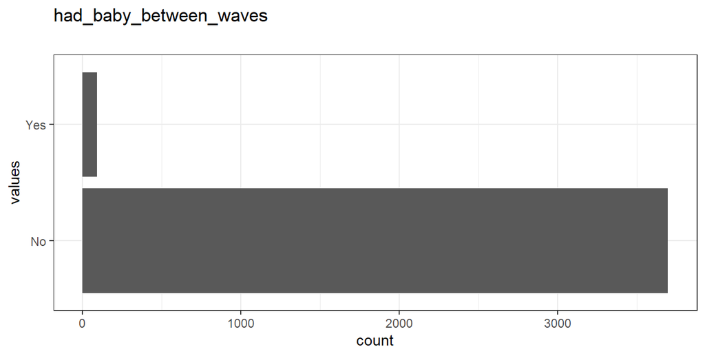

Distribution of values for had_baby_between_waves

0 missing values.

###### Summary statistics

| name | data_type | ordered | value_labels | n_missing | complete_rate | n_unique | top_counts | label |
| --- | --- | --- | --- | --- | --- | --- | --- | --- |
| had_baby_between_waves | factor | FALSE | 1. No, 2. Yes | 0 | 1 | 2 | No: 3697, Yes: 90 | NA |

##### Avoid_r

###### Distribution

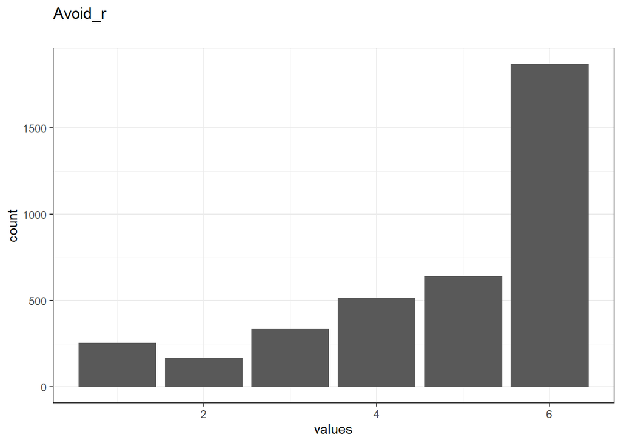

Distribution of values for Avoid_r

0 missing values.

###### Summary statistics

| name | data_type | n_missing | complete_rate | min | median | max | mean | sd | hist | label |
| --- | --- | --- | --- | --- | --- | --- | --- | --- | --- | --- |
| Avoid_r | numeric | 0 | 1 | 1 | 5 | 6 | 4.777396 | 1.55302 | ▂▂▂▃▇ | NA |

##### FEELPG_recode

###### Distribution

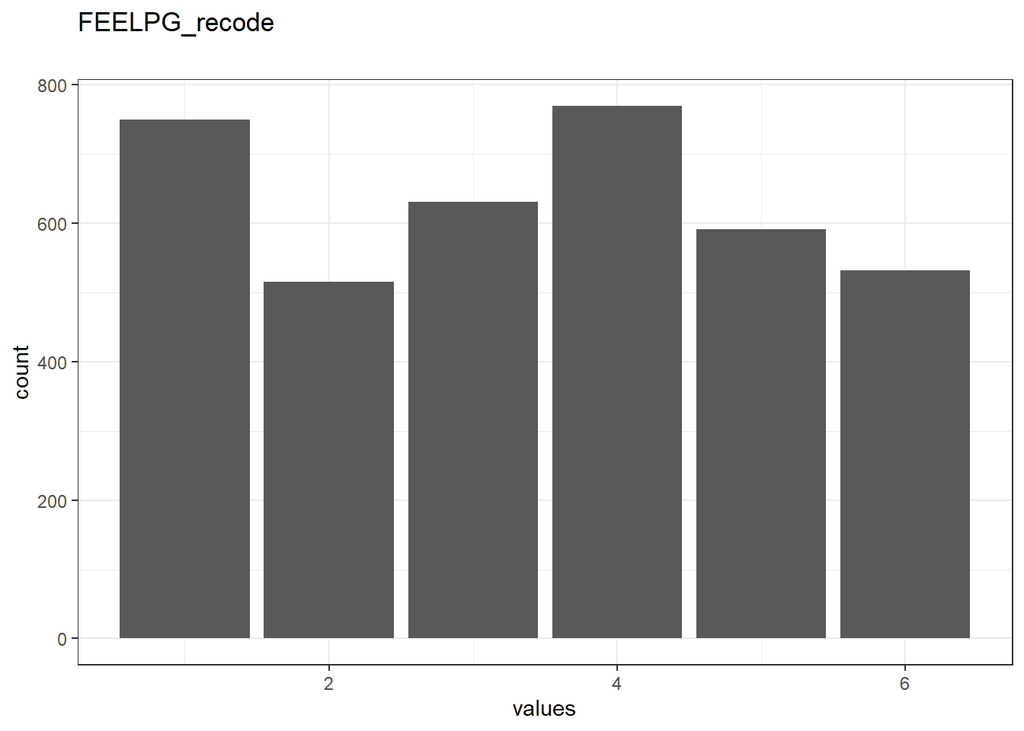

Distribution of values for FEELPG_recode

0 missing values.

###### Summary statistics

| name | data_type | n_missing | complete_rate | min | median | max | mean | sd | hist | label |
| --- | --- | --- | --- | --- | --- | --- | --- | --- | --- | --- |
| FEELPG_recode | numeric | 0 | 1 | 1 | 3 | 6 | 3.40507 | 1.689799 | ▇▃▅▃▃ | NA |

##### rel_dur_factor

###### Distribution

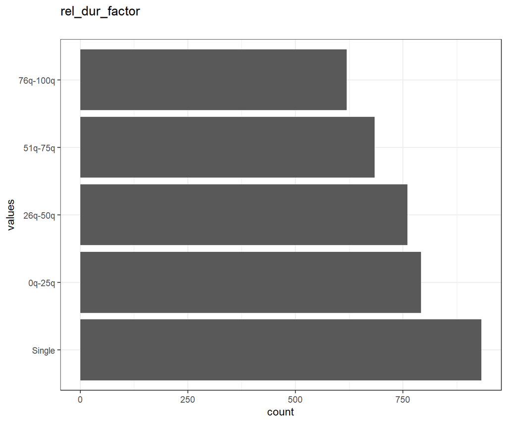

Distribution of values for rel_dur_factor

0 missing values.

###### Summary statistics

| name | data_type | ordered | value_labels | n_missing | complete_rate | n_unique | top_counts | label |
| --- | --- | --- | --- | --- | --- | --- | --- | --- |
| rel_dur_factor | factor | FALSE | 1. Single, 2. 0q-25q, 3. 26q-50q, 4. 51q-75q, 5. 76q-100q | 0 | 1 | 5 | Sin: 932, 0q-: 792, 26q: 760, 51q: 684 | NA |

#### Codebook table

| name | data_type | ordered | value_labels | n_missing | complete_rate | n_unique | top_counts | min | median | max | mean | sd | hist | label |
| --- | --- | --- | --- | --- | --- | --- | --- | --- | --- | --- | --- | --- | --- | --- |
| WAVE | factor | FALSE | 1. t1, 2. t2, 3. t3, 4. t4 | 0 | 1.00000 | 3 | t1: 1723, t2: 1181, t3: 883, t4: 0 | NA | NA | NA | NA | NA | NA | NA |
| switch | numeric | NA | NA | 0 | 1.00000 | NA | NA | 0 | 0 | 1 | 0.1280697 | 0.3342115 | ▇▁▁▁▁ | NA |
| hc | factor | FALSE | 1. hc, 2. non_hc, 3. IUD&non_hc | 0 | 1.00000 | 2 | hc: 2294, non: 1493, IUD: 0 | NA | NA | NA | NA | NA | NA | NA |
| contra_satis | numeric | NA | NA | 0 | 1.00000 | NA | NA | 1 | 4 | 4 | 3.4861368 | 0.7016738 | ▁▁▁▅▇ | NA |
| hc_dur | numeric | NA | NA | 1502 | 0.60338 | NA | NA | 0 | 10 | 41 | 10.9899344 | 6.7531133 | ▇▇▃▁▁ | NA |
| sexual_satisfaction | numeric | NA | NA | 0 | 1.00000 | NA | NA | 1 | 5 | 6 | 5.0166359 | 1.1567519 | ▁▁▃▅▇ | NA |
| sex_freq | factor | FALSE | 1. No sex or once, 2. 2-5 times, 3. 6-10 times, 4. 11 or more times | 0 | 1.00000 | 4 | 2-5: 1659, 6-1: 1036, 11 : 594, No : 498 | NA | NA | NA | NA | NA | NA | NA |
| AGE | numeric | NA | NA | 0 | 1.00000 | NA | NA | 18 | 27 | 39 | 28.1528915 | 5.2094655 | ▃▇▆▅▅ | NA |
| DEGREE_recode | factor | FALSE | 1. no formal education, 2. 1st to 4th grade, 3. 5th/6th grade, 4. 7th/8th grade, 5. 9th grade, 6. 10th grade, 7. 11th grade, 8. 12th grade / no diploma, 9. high school diploma or equivalent, 10. some … | 0 | 1.00000 | 13 | bac: 1364, som: 924, mas: 442, hig: 421 | NA | NA | NA | NA | NA | NA | NA |
| POVRATE | numeric | NA | NA | 0 | 1.00000 | NA | NA | 14 | 282 | 1532 | 320.1457618 | 231.8161327 | ▇▅▁▁▁ | NA |
| HLTHPROB_recode | factor | FALSE | 1. No, 2. Yes | 0 | 1.00000 | 2 | No: 3125, Yes: 662 | NA | NA | NA | NA | NA | NA | NA |
| MEDPROB_recode | factor | FALSE | 1. No, 2. Yes | 0 | 1.00000 | 2 | No: 3444, Yes: 343 | NA | NA | NA | NA | NA | NA | NA |
| GAPINS_recode | factor | FALSE | 1. No, 2. Yes | 0 | 1.00000 | 2 | No: 3076, Yes: 711 | NA | NA | NA | NA | NA | NA | NA |
| TYPEINS_recode | factor | FALSE | 1. No, 2. Yes | 0 | 1.00000 | 2 | Yes: 3218, No: 569 | NA | NA | NA | NA | NA | NA | NA |
| NKIDS_t1 | factor | FALSE | 1. 0, 2. 1, 3. 2, 4. 3, 5. 4 or more | 0 | 1.00000 | 5 | 0: 2121, 1: 704, 2: 631, 3: 216 | NA | NA | NA | NA | NA | NA | NA |
| pregnant_between_waves | factor | FALSE | 1. No, 2. Yes | 0 | 1.00000 | 2 | No: 3655, Yes: 132 | NA | NA | NA | NA | NA | NA | NA |
| had_baby_between_waves | factor | FALSE | 1. No, 2. Yes | 0 | 1.00000 | 2 | No: 3697, Yes: 90 | NA | NA | NA | NA | NA | NA | NA |
| Avoid_r | numeric | NA | NA | 0 | 1.00000 | NA | NA | 1 | 5 | 6 | 4.7773964 | 1.5530201 | ▂▂▂▃▇ | NA |
| FEELPG_recode | numeric | NA | NA | 0 | 1.00000 | NA | NA | 1 | 3 | 6 | 3.4050700 | 1.6897990 | ▇▃▅▃▃ | NA |
| rel_dur_factor | factor | FALSE | 1. Single, 2. 0q-25q, 3. 26q-50q, 4. 51q-75q, 5. 76q-100q | 0 | 1.00000 | 5 | Sin: 932, 0q-: 792, 26q: 760, 51q: 684 | NA | NA | NA | NA | NA | NA | NA |

**JSON-LD metadata**

The following JSON-LD can be found by search engines, if you share this codebook publicly on the web.

```json
{
  "name": "cccu_MA",
  "datePublished": "2022-08-13",
  "description": "The dataset has N=3787 rows and 20 columns.\n2285 rows have no missing values on any column.\n\n\n## Table of variables\nThis table contains variable names, labels, and number of missing values.\nSee the complete codebook for more.\n\n|name                   |label | n_missing|\n|:----------------------|:-----|---------:|\n|WAVE                   |NA    |         0|\n|switch                 |NA    |         0|\n|hc                     |NA    |         0|\n|contra_satis           |NA    |         0|\n|hc_dur                 |NA    |      1502|\n|sexual_satisfaction    |NA    |         0|\n|sex_freq               |NA    |         0|\n|AGE                    |NA    |         0|\n|DEGREE_recode          |NA    |         0|\n|POVRATE                |NA    |         0|\n|HLTHPROB_recode        |NA    |         0|\n|MEDPROB_recode         |NA    |         0|\n|GAPINS_recode          |NA    |         0|\n|TYPEINS_recode         |NA    |         0|\n|NKIDS_t1               |NA    |         0|\n|pregnant_between_waves |NA    |         0|\n|had_baby_between_waves |NA    |         0|\n|Avoid_r                |NA    |         0|\n|FEELPG_recode          |NA    |         0|\n|rel_dur_factor         |NA    |         0|\n\n### Note\nThis dataset was automatically described using the [codebook R package](https://rubenarslan.github.io/codebook/) (version 0.9.2).",
  "keywords": ["WAVE", "switch", "hc", "contra_satis", "hc_dur", "sexual_satisfaction", "sex_freq", "AGE", "DEGREE_recode", "POVRATE", "HLTHPROB_recode", "MEDPROB_recode", "GAPINS_recode", "TYPEINS_recode", "NKIDS_t1", "pregnant_between_waves", "had_baby_between_waves", "Avoid_r", "FEELPG_recode", "rel_dur_factor"],
  "@context": "http://schema.org/",
  "@type": "Dataset",
  "variableMeasured": [
    {
      "name": "WAVE",
      "value": "1. t1,\n2. t2,\n3. t3,\n4. t4",
      "@type": "propertyValue"
    },
    {
      "name": "switch",
      "@type": "propertyValue"
    },
    {
      "name": "hc",
      "value": "1. hc,\n2. non_hc,\n3. IUD&non_hc",
      "@type": "propertyValue"
    },
    {
      "name": "contra_satis",
      "@type": "propertyValue"
    },
    {
      "name": "hc_dur",
      "@type": "propertyValue"
    },
    {
      "name": "sexual_satisfaction",
      "@type": "propertyValue"
    },
    {
      "name": "sex_freq",
      "value": "1. No sex or once,\n2. 2-5 times,\n3. 6-10 times,\n4. 11 or more times",
      "@type": "propertyValue"
    },
    {
      "name": "AGE",
      "@type": "propertyValue"
    },
    {
      "name": "DEGREE_recode",
      "value": "1. no formal education,\n2. 1st to 4th grade,\n3. 5th/6th grade,\n4. 7th/8th grade,\n5. 9th grade,\n6. 10th grade,\n7. 11th grade,\n8. 12th grade / no diploma,\n9. high school diploma or equivalent,\n10. some college, no degree,\n11. associate degree,\n12. bachelors degree,\n13. masters degree,\n14. professional or doctoral degree",
      "@type": "propertyValue"
    },
    {
      "name": "POVRATE",
      "@type": "propertyValue"
    },
    {
      "name": "HLTHPROB_recode",
      "value": "1. No,\n2. Yes",
      "@type": "propertyValue"
    },
    {
      "name": "MEDPROB_recode",
      "value": "1. No,\n2. Yes",
      "@type": "propertyValue"
    },
    {
      "name": "GAPINS_recode",
      "value": "1. No,\n2. Yes",
      "@type": "propertyValue"
    },
    {
      "name": "TYPEINS_recode",
      "value": "1. No,\n2. Yes",
      "@type": "propertyValue"
    },
    {
      "name": "NKIDS_t1",
      "value": "1. 0,\n2. 1,\n3. 2,\n4. 3,\n5. 4 or more",
      "@type": "propertyValue"
    },
    {
      "name": "pregnant_between_waves",
      "value": "1. No,\n2. Yes",
      "@type": "propertyValue"
    },
    {
      "name": "had_baby_between_waves",
      "value": "1. No,\n2. Yes",
      "@type": "propertyValue"
    },
    {
      "name": "Avoid_r",
      "@type": "propertyValue"
    },
    {
      "name": "FEELPG_recode",
      "@type": "propertyValue"
    },
    {
      "name": "rel_dur_factor",
      "value": "1. Single,\n2. 0q-25q,\n3. 26q-50q,\n4. 51q-75q,\n5. 76q-100q",
      "@type": "propertyValue"
    }
  ]
}`
```

#Plots

#Correlations

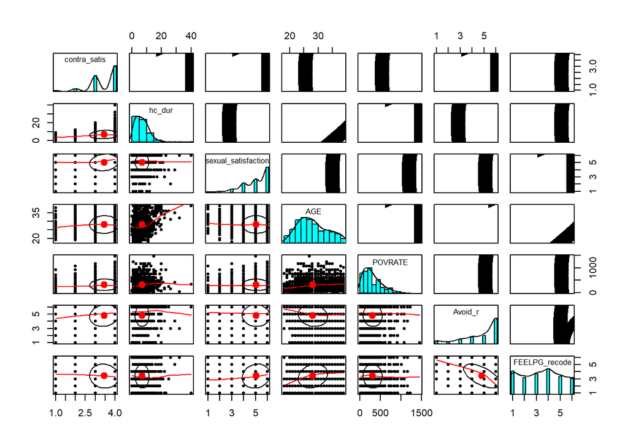

```r
#for t1
cccu_MA_t1 <- cccu_MA%>%
  filter(WAVE == "t1")
cccu_MA_t1_correlations <- cccu_MA_t1 %>%
  select(contra_satis, hc_dur,
    sexual_satisfaction,
    AGE, POVRATE, Avoid_r, FEELPG_recode)


pairs.panels(cccu_MA_t1_correlations, cex.cor = 10)
```

```r
rcorr(as.matrix(cccu_MA_t1_correlations))
```

```
##                     contra_satis hc_dur sexual_satisfaction   AGE POVRATE
## contra_satis                1.00   0.15                0.16  0.02    0.06
## hc_dur                      0.15   1.00                0.01  0.25    0.15
## sexual_satisfaction         0.16   0.01                1.00 -0.03   -0.01
## AGE                         0.02   0.25               -0.03  1.00    0.18
## POVRATE                     0.06   0.15               -0.01  0.18    1.00
## Avoid_r                     0.13   0.02               -0.03 -0.14   -0.02
## FEELPG_recode              -0.06  -0.03                0.12  0.20   -0.04
##                     Avoid_r FEELPG_recode
## contra_satis           0.13         -0.06
## hc_dur                 0.02         -0.03
## sexual_satisfaction   -0.03          0.12
## AGE                   -0.14          0.20
## POVRATE               -0.02         -0.04
## Avoid_r                1.00         -0.61
## FEELPG_recode         -0.61          1.00
##
## n
##                     contra_satis hc_dur sexual_satisfaction  AGE POVRATE
## contra_satis                1723   1032                1723 1723    1723
## hc_dur                      1032   1032                1032 1032    1032
## sexual_satisfaction         1723   1032                1723 1723    1723
## AGE                         1723   1032                1723 1723    1723
## POVRATE                     1723   1032                1723 1723    1723
## Avoid_r                     1723   1032                1723 1723    1723
## FEELPG_recode               1723   1032                1723 1723    1723
##                     Avoid_r FEELPG_recode
## contra_satis           1723          1723
## hc_dur                 1032          1032
## sexual_satisfaction    1723          1723
## AGE                    1723          1723
## POVRATE                1723          1723
## Avoid_r                1723          1723
## FEELPG_recode          1723          1723
##
## P
##                     contra_satis hc_dur sexual_satisfaction AGE    POVRATE
## contra_satis                     0.0000 0.0000              0.4981 0.0177
## hc_dur              0.0000              0.8285              0.0000 0.0000
## sexual_satisfaction 0.0000       0.8285                     0.1895 0.6176
## AGE                 0.4981       0.0000 0.1895                     0.0000
## POVRATE             0.0177       0.0000 0.6176              0.0000
## Avoid_r             0.0000       0.5793 0.1834              0.0000 0.4026
## FEELPG_recode       0.0084       0.2867 0.0000              0.0000 0.1272
##                     Avoid_r FEELPG_recode
## contra_satis        0.0000  0.0084
## hc_dur              0.5793  0.2867
## sexual_satisfaction 0.1834  0.0000
## AGE                 0.0000  0.0000
## POVRATE             0.4026  0.1272
## Avoid_r                     0.0000
## FEELPG_recode       0.0000
```

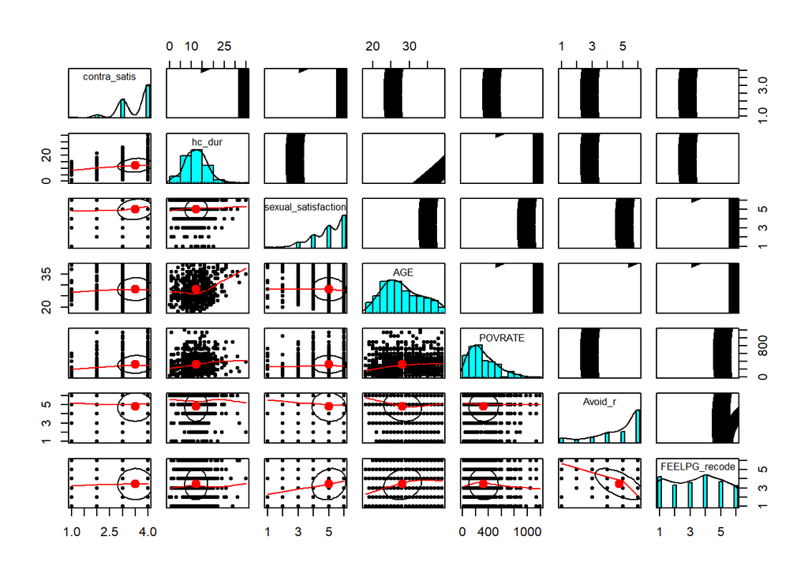

```r
#for t2
cccu_MA_t2 <- cccu_MA%>%
  filter(WAVE == "t2")

cccu_MA_t2_correlations <- cccu_MA_t2 %>%
  select(contra_satis, hc_dur,
    sexual_satisfaction,
    AGE, POVRATE, Avoid_r, FEELPG_recode)
pairs.panels(cccu_MA_t2_correlations, cex.cor = 10)
```

```r
rcorr(as.matrix(cccu_MA_t2_correlations))
```

```
##                     contra_satis hc_dur sexual_satisfaction   AGE POVRATE
## contra_satis                1.00   0.15                0.14  0.01    0.06
## hc_dur                      0.15   1.00                0.04  0.20    0.16
## sexual_satisfaction         0.14   0.04                1.00 -0.05   -0.01
## AGE                         0.01   0.20               -0.05  1.00    0.16
## POVRATE                     0.06   0.16               -0.01  0.16    1.00
## Avoid_r                     0.04   0.05               -0.08 -0.14    0.00
## FEELPG_recode               0.00   0.01                0.18  0.19   -0.04
##                     Avoid_r FEELPG_recode
## contra_satis           0.04          0.00
## hc_dur                 0.05          0.01
## sexual_satisfaction   -0.08          0.18
## AGE                   -0.14          0.19
## POVRATE                0.00         -0.04
## Avoid_r                1.00         -0.62
## FEELPG_recode         -0.62          1.00
##
## n
##                     contra_satis hc_dur sexual_satisfaction  AGE POVRATE
## contra_satis                1181    717                1181 1181    1181
## hc_dur                       717    717                 717  717     717
## sexual_satisfaction         1181    717                1181 1181    1181
## AGE                         1181    717                1181 1181    1181
## POVRATE                     1181    717                1181 1181    1181
## Avoid_r                     1181    717                1181 1181    1181
## FEELPG_recode               1181    717                1181 1181    1181
##                     Avoid_r FEELPG_recode
## contra_satis           1181          1181
## hc_dur                  717           717
## sexual_satisfaction    1181          1181
## AGE                    1181          1181
## POVRATE                1181          1181
## Avoid_r                1181          1181
## FEELPG_recode          1181          1181
##
## P
##                     contra_satis hc_dur sexual_satisfaction AGE    POVRATE
## contra_satis                     0.0000 0.0000              0.6556 0.0531
## hc_dur              0.0000              0.2944              0.0000 0.0000
## sexual_satisfaction 0.0000       0.2944                     0.1034 0.7755
## AGE                 0.6556       0.0000 0.1034                     0.0000
## POVRATE             0.0531       0.0000 0.7755              0.0000
## Avoid_r             0.1471       0.1944 0.0098              0.0000 0.9078
## FEELPG_recode       0.8963       0.8778 0.0000              0.0000 0.2005
##                     Avoid_r FEELPG_recode
## contra_satis        0.1471  0.8963
## hc_dur              0.1944  0.8778
## sexual_satisfaction 0.0098  0.0000
## AGE                 0.0000  0.0000
## POVRATE             0.9078  0.2005
## Avoid_r                     0.0000
## FEELPG_recode       0.0000
```

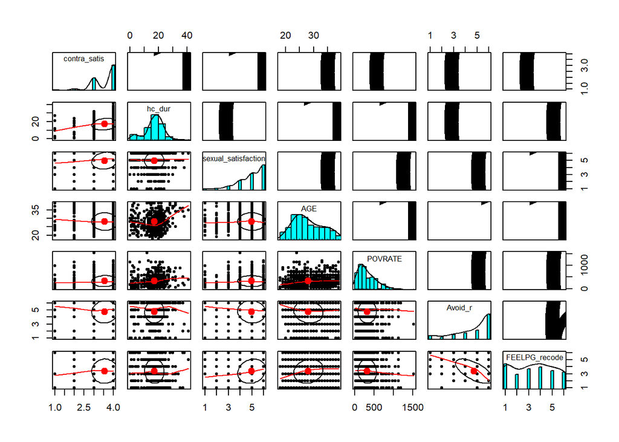

```r
#for t3
cccu_MA_t3 <- cccu_MA%>%
  filter(WAVE == "t3")

cccu_MA_t3_correlations <- cccu_MA_t3 %>%
  select(contra_satis, hc_dur,
    sexual_satisfaction,
    AGE, POVRATE, Avoid_r, FEELPG_recode)

pairs.panels(cccu_MA_t3_correlations, cex.cor = 10)
```

```r
rcorr(as.matrix(cccu_MA_t3_correlations))
```

```
##                     contra_satis hc_dur sexual_satisfaction   AGE POVRATE
## contra_satis                1.00   0.17                0.14 -0.02    0.06
## hc_dur                      0.17   1.00                0.03  0.11    0.12
## sexual_satisfaction         0.14   0.03                1.00 -0.01   -0.02
## AGE                        -0.02   0.11               -0.01  1.00    0.16
## POVRATE                     0.06   0.12               -0.02  0.16    1.00
## Avoid_r                     0.05   0.01               -0.07 -0.12   -0.02
## FEELPG_recode               0.01  -0.02                0.16  0.16   -0.06
##                     Avoid_r FEELPG_recode
## contra_satis           0.05          0.01
## hc_dur                 0.01         -0.02
## sexual_satisfaction   -0.07          0.16
## AGE                   -0.12          0.16
## POVRATE               -0.02         -0.06
## Avoid_r                1.00         -0.64
## FEELPG_recode         -0.64          1.00
##
## n
##                     contra_satis hc_dur sexual_satisfaction AGE POVRATE Avoid_r
## contra_satis                 883    536                 883 883     883     883
## hc_dur                       536    536                 536 536     536     536
## sexual_satisfaction          883    536                 883 883     883     883
## AGE                          883    536                 883 883     883     883
## POVRATE                      883    536                 883 883     883     883
## Avoid_r                      883    536                 883 883     883     883
## FEELPG_recode                883    536                 883 883     883     883
##                     FEELPG_recode
## contra_satis                  883
## hc_dur                        536
## sexual_satisfaction           883
## AGE                           883
## POVRATE                       883
## Avoid_r                       883
## FEELPG_recode                 883
##
## P
##                     contra_satis hc_dur sexual_satisfaction AGE    POVRATE
## contra_satis                     0.0000 0.0000              0.6369 0.0580
## hc_dur              0.0000              0.4937              0.0095 0.0059
## sexual_satisfaction 0.0000       0.4937                     0.8171 0.5747
## AGE                 0.6369       0.0095 0.8171                     0.0000
## POVRATE             0.0580       0.0059 0.5747              0.0000
## Avoid_r             0.1777       0.9037 0.0373              0.0004 0.5264
## FEELPG_recode       0.7616       0.6797 0.0000              0.0000 0.0715
##                     Avoid_r FEELPG_recode
## contra_satis        0.1777  0.7616
## hc_dur              0.9037  0.6797
## sexual_satisfaction 0.0373  0.0000
## AGE                 0.0004  0.0000
## POVRATE             0.5264  0.0715
## Avoid_r                     0.0000
## FEELPG_recode       0.0000
```